# Data Analysis Project: Exploratory Analysis

Bryan Gallion

Nov. 3, 2019

## Objective

This markdown file includes initial attempts at loading, cleaning, understanding and analyzing data for the analysis project.

I’ll be looking at the relationship between opioid use and homelessness in the Kensington neighborhood of Philadelphia. The city is tackling the two epidemics together, so I want to look deeper into the correlation between them.

For comparison, I’ll also be analyzing nationwide data to see how Kensington compares to country wide trends.

Some questions that could motivate my work include: Does drug use in Kensington correlate with homelessness rates in the neighborhood? Is opioid use decreasing over time as homeless encampments are being cleared from the city’s streets? How do Kensington’s homeless and opioid rates compare to trends seen throughout the U.S.?

I’m going to look at opioid data from the Washington Post’s ARCOS R package, specifically focusing on shipments sent to the zip code sent to Kensington. I’m also going to look at Point-in-Time data to see how the opioid use and homeless rates connect over the seven-year period that the ARCOS database tracks. Sean will also be providing a crosswalk of opioid and homeless data that I will analyze.

## Load Necessary Packages

```r
# Load Tidyverse, janitor, arcos, tidycensus
library(tidyverse)
library(janitor)
library(arcos)
library(tidycensus)
```

## Store API Key

```r
# Store an API key as an object called key
key <- "uO4EK6I"
```

## Load ARCOS data

```r
# Get annual total pills for each buyer (pharmacy, etc.) in a county
arcos_buyer_yearly <- combined_buyer_annual(key=key) %>%
  clean_names()

# Load buyer_addresses
buyer_addresses <- read_csv("data/buyer_addresses.csv")
# Load buyer_totals
buyer_totals <- read_csv("data/buyer_totals.csv")
# Load buyer_annual_by_year
buyer_annual_by_year <- read_csv("data/buyer_annual_by_year.csv")
# Load state_population_per_year
state_population_per_year <- read_csv("data/state_population_per_year.csv")
#Load arcos raw data for Philadelphia
arcos_philadelphia_raw <- read_tsv("data/arcos-pa-philadelphia-42101-itemized.tsv") %>%
  clean_names()
```

## Calculate Pills Per State and County

1. How many opioid pills were shipped to each state between 2006 and 2012? And where does Pennsylvania rank on the list?

```r
# Group by buyer state, summarize the total pills each received and rank descending
arcos_buyer_yearly %>%
  group_by(buyer_state) %>%
  summarise(total_pills = sum(dosage_unit)
    ) %>%
  arrange(desc(total_pills))
```

```
## # A tibble: 58 x 2
##    buyer_state total_pills
##    <chr>             <dbl>
##  1 CA          8057291423.
##  2 FL          5558242471.
##  3 TX          5432135664.
##  4 OH          3397984780.
##  5 NY          3338304694.
##  6 PA          3088637076.
##  7 MI          2852578277
##  8 NC          2552612398.
##  9 TN          2519779525.
## 10 GA          2270981867.
## # … with 48 more rows
```

```r
# Pennsylvania received 3,088,637,076 pills during the years tracked in the AROCS database, ranking sixth among all states in the U.S. The state's total came in behind California, Florida, Texas, Ohio and New York.
```

2. How many pills per shipment did each state receive? And where did Pennsylvania rank?

```r
# Group by buyer state, summarize the totals pills per shipment and rank descending
arcos_buyer_yearly %>%
  group_by(buyer_state) %>%
  summarise(shipments = n(),
            total_pills = sum(dosage_unit),
            avg_pills_per_shipment = mean(dosage_unit)
            ) %>%
  arrange(desc(avg_pills_per_shipment))
```

```
## # A tibble: 58 x 4
##    buyer_state shipments total_pills avg_pills_per_shipment
##    <chr>           <int>       <dbl>                  <dbl>
##  1 KY               8973 1901662933.                211932.
##  2 NV               4739 1002583755                 211560.
##  3 SC               9424 1832404651.                194440.
##  4 WV               4552  853490268.                187498.
##  5 NM               2894  522109039                 180411.
##  6 OR               7449 1336351877                 179400.
##  7 OK               8003 1403265597.                175342.
##  8 DE               1628  276177276                 169642.
##  9 IN              12616 2123679139                 168332.
## 10 KS               5272  875161421                 166002.
## # … with 48 more rows
```

```r
# While Pennsylvania ranked near the top of the list of states in terms of total pills received, it ranked 31st in average pills per shipment -- 116,649.18. Even though it received a large number of pills between 2006 and 2012, the shipments weren't as massive on average compared to many other states.
```

3. When looking only at Pennsylvania counties, where does Philadelphia rank in terms of total pills received between 2006 and 2012?

```r
# Group by buyer county, filter for Pennsylvania counties only, summarize total pills and arrange descending
arcos_buyer_yearly %>%
  group_by(buyer_county) %>%
  filter(buyer_state == "PA") %>%
  summarise(total_pills = sum(dosage_unit)
    ) %>%
  arrange(desc(total_pills))
```

```
## # A tibble: 67 x 2
##    buyer_county total_pills
##    <chr>              <dbl>
##  1 PHILADELPHIA  394047551
##  2 ALLEGHENY     338716252.
##  3 MONTGOMERY    193652578
##  4 BUCKS         165738590.
##  5 DELAWARE      164134934
##  6 LANCASTER     101334233
##  7 WESTMORELAND   99918295
##  8 LUZERNE        91137991
##  9 YORK           81408034.
## 10 LACKAWANNA     79029884
## # … with 57 more rows
```

```r
# Philadelphia received the most pills out of all Pennsylvania counties: 394,047,551. The next-highest -- Allegheny -- received 338,716,252, followed by Montgomery County with 193,652,578.
```

4. Where does Phildelphia rank in terms of pills per shipment?

```r
# Group by buyer county, filter for Pennsylvania counties only, summarize average pills per shipment and arrange descending
arcos_buyer_yearly %>%
  group_by(buyer_county) %>%
  filter(buyer_state == "PA") %>%
  summarise(shipments = n(),
            total_pills = sum(dosage_unit),
            avg_pills_per_shipment = mean(dosage_unit)
            ) %>%
  arrange(desc(avg_pills_per_shipment))
```

```
## # A tibble: 67 x 4
##    buyer_county shipments total_pills avg_pills_per_shipment
##    <chr>            <int>       <dbl>                  <dbl>
##  1 CAMBRIA            319    62327100                195383.
##  2 CARBON             123    19951456                162207.
##  3 FAYETTE            383    58339550                152323.
##  4 CLINTON             68    10309060                151604.
##  5 LAWRENCE           215    32474100                151042.
##  6 WAYNE               96    13884070                144626.
##  7 MONROE             305    43803659                143619.
##  8 SCHUYLKILL         278    39413590                141776.
##  9 ERIE               539    76283755                141528.
## 10 POTTER              29     4101610                141435.
## # … with 57 more rows
```

```r
# Philadelphia ranked 25th among Pennsylvania counties in terms of average pills per shipment with 127,112.11, despite receiving the most pills overall during the time tracked by the ARCOS database.
```

5. What was the year-over-year trend like for the number of pills sent to Pennsylvania?

```r
# Group by year, filter for Pennsylvania and summarize total pills per year
arcos_buyer_yearly %>%
  group_by(year) %>%
  filter(buyer_state == "PA") %>%
  summarise(total_pills = sum(dosage_unit)
            ) %>%
  arrange(year)
```

```
## # A tibble: 7 x 2
##    year total_pills
##   <int>       <dbl>
## 1  2006  327713124.
## 2  2007  375759842
## 3  2008  415170927
## 4  2009  450651373.
## 5  2010  475335790.
## 6  2011  518398665.
## 7  2012  525607355
```

```r
# The number of pills shipped to Pennsylvania each year increased between 2006 and 2012, but at different rates between every year. The state received about 48 million more pills in 2007 than in 2006, about 39 million more in 2008 than in 2007, about  36 million more in 2009 than in 2008, and about 25 million more in 2010 than in 2009. The number of pills shot up by about 43 million more in 2011 than in 2010 but only by about 7 million more in 2012 than in 2011.
```

6. What was the year-over-year trend for the number of pills sent to Philadelphia?

```r
# Group by year, filter for Philadelphia and Pennsylvania, and summarize total pills per year
arcos_buyer_yearly %>%
  group_by(year) %>%
  filter(buyer_state == "PA", buyer_county == "PHILADELPHIA") %>%
  summarise(total_pills = sum(dosage_unit)
            ) %>%
  arrange(year)
```

```
## # A tibble: 7 x 2
##    year total_pills
##   <int>       <dbl>
## 1  2006    42155735
## 2  2007    46336784
## 3  2008    52249920
## 4  2009    56174306
## 5  2010    60170212
## 6  2011    68582534
## 7  2012    68378060
```

```r
# Philadelphia continued to receive more and more pills each year, until the number of total annual pills it received decreased in 2012 -- much like the statewide trend only increased marginally in 2012. What happend that year to see not as much of an increase in the number of pills shipped to Philadelphia and Pennsylvania overall?
```

7. What does this year-over-year trend look like visually?

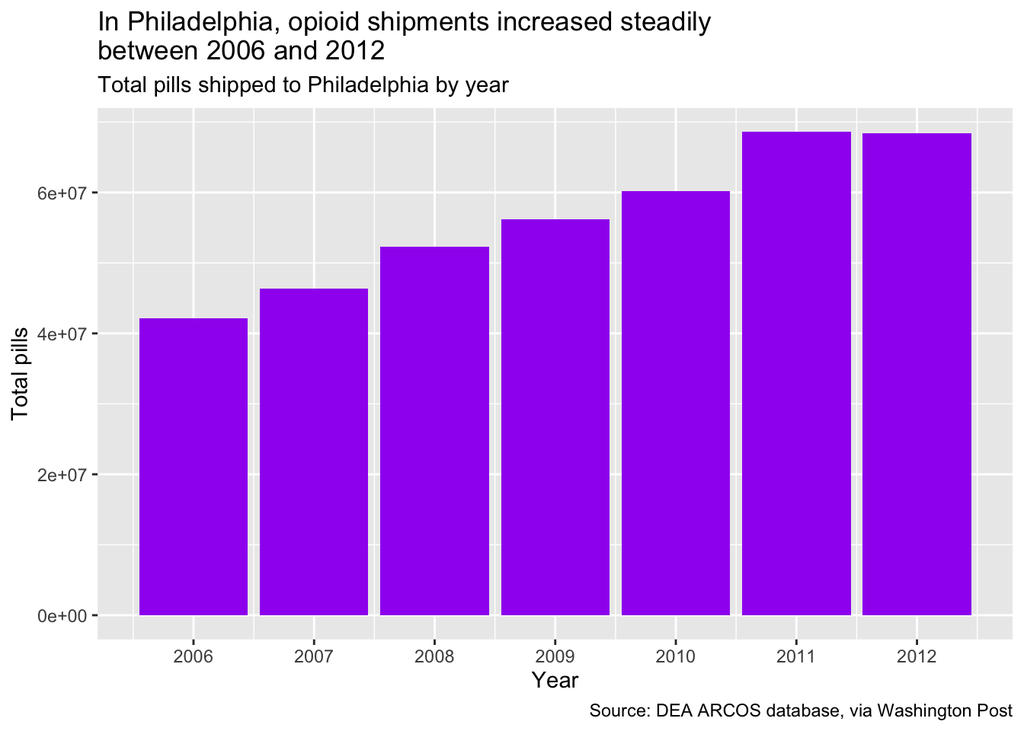

```r
# Load county data
arcos_county_pills_per_year <- summarized_county_annual(key = key) %>%
  clean_names()

# Create object for only Philadelphia data
philadelphia_pills_per_year <- arcos_county_pills_per_year %>%
  filter(buyer_state == "PA", buyer_county == "PHILADELPHIA") %>%
  select(year, dosage_unit)

# Create a bar chart for shipments received each year between 2006 and 2012
ggplot(philadelphia_pills_per_year) +
  geom_bar(stat="identity", aes(year, dosage_unit), fill="purple") +
  labs(x="Year", y="Total pills", title="In Philadelphia, opioid shipments increased steadily \nbetween 2006 and 2012", subtitle = "Total pills shipped to Philadelphia by year", caption = "Source: DEA ARCOS database, via Washington Post") +
  scale_x_continuous(breaks = c(2006, 2007, 2008, 2009, 2010, 2011, 2012))
```

```r
# Turn off scientific notation
options(scipen=999)

# Philadelphia received a massive number of pills during the period tracked by the ARCOS database -- almost 70 million by 2012. The number of pills per year steadily increased over this seven-year span. Seeing the change over time prompts many questions to look into further: Was no one catching on to how extreme the opioid epidemic was in the city during this time? Did any pharmacies get in trouble?
```

## Calculating Pills Per Person

8. Which state received the highest rate of pills per person? Where does Pennsylvania rank?

```r
# Join buyer_totals and state_population_per_year and calculate the rate of pills per person
buyer_totals %>%
  inner_join(state_population_per_year, by="buyer_state") %>%
  group_by(buyer_state, population_average) %>%
  summarise(total_pills_by_state = sum(total_pills)) %>%
  mutate(rate = total_pills_by_state/population_average) %>%
  arrange(desc(rate))
```

```
## # A tibble: 51 x 4
## # Groups:   buyer_state [51]
##    buyer_state population_average total_pills_by_state  rate
##    <chr>                    <dbl>                <dbl> <dbl>
##  1 WV                     1835903           853490268.  465.
##  2 KY                     4279971          1901662933.  444.
##  3 SC                     4495067          1832404651.  408.
##  4 TN                     6222433          2519779525.  405.
##  5 OK                     3663764          1403265597.  383.
##  6 NV                     2619151          1002583755   383.
##  7 AL                     4698683          1703753240.  363.
##  8 OR                     3755715          1336351877   356.
##  9 IN                     6405249          2123679139   332.
## 10 DE                      878712           276177276   314.
## # … with 41 more rows
```

```r
# West Virginia received the highest rate of pills per person. It received 853,490,268 pills with a population average of 1,835,903, which results in a rate of 464.9 pills per person. Pennsylvania ranked 27th among U.S. states. It received 308,863,7076 pills with an average population of 12,596,665, which equals a pills per person rate of 245.2.
```

9. How many pills per person did Philadelphia receive? How does this rate compare to other Pennsylvania counties?

```r
# Filter the nationwide buyer data to narrow in on Pennsylvania counties
pa_buyer_total <- arcos_buyer_yearly %>%
  group_by(buyer_county) %>%
  filter(buyer_state == "PA") %>%
  summarise(total_pills = sum(dosage_unit)
    ) %>%
  arrange(desc(total_pills))
```

```r
# Filter the nationwide county population data to narrow in on Pennsylvania
county_population(key=key, state="PA") %>%
  summarise()
```

```
## data frame with 0 columns and 1 row
```

```r
# Having trouble with this question -- I know I have to join population and pills, but how do I average the population for the seven years tracked?
```

## Summarizing Shipments to Philadelphia Pharmacies

10. Summarize the raw ARCOS database for Philadelphia counties. What information from this summary is telling about the shipments received by Philadelphia pharmacies during the time tracked in the ARCOS database?

```r
summary(arcos_philadelphia_raw)
```

```
##  reporter_dea_no    reporter_bus_act   reporter_name
##  Length:792500      Length:792500      Length:792500
##  Class :character   Class :character   Class :character
##  Mode  :character   Mode  :character   Mode  :character
##
##
##
##  reporter_addl_co_info reporter_address1  reporter_address2
##  Length:792500         Length:792500      Length:792500
##  Class :character      Class :character   Class :character
##  Mode  :character      Mode  :character   Mode  :character
##
##
##
##  reporter_city      reporter_state      reporter_zip   reporter_county
##  Length:792500      Length:792500      Min.   : 1434   Length:792500
##  Class :character   Class :character   1st Qu.: 8075   Class :character
##  Mode  :character   Mode  :character   Median : 8086   Mode  :character
##                                        Mean   :13495
##                                        3rd Qu.:11357
##                                        Max.   :99518
##  buyer_dea_no       buyer_bus_act       buyer_name
##  Length:792500      Length:792500      Length:792500
##  Class :character   Class :character   Class :character
##  Mode  :character   Mode  :character   Mode  :character
##
##
##
##  buyer_addl_co_info buyer_address1     buyer_address2
##  Length:792500      Length:792500      Length:792500
##  Class :character   Class :character   Class :character
##  Mode  :character   Mode  :character   Mode  :character
##
##
##
##   buyer_city        buyer_state          buyer_zip     buyer_county
##  Length:792500      Length:792500      Min.   :19102   Length:792500
##  Class :character   Class :character   1st Qu.:19120   Class :character
##  Mode  :character   Mode  :character   Median :19134   Mode  :character
##                                        Mean   :19132
```

[output cut: 36 more lines]

```
##  Max.   :1212147235
##    measure          mme_conversion_factor combined_labeler_name
##  Length:792500      Min.   :1.000         Length:792500
##  Class :character   1st Qu.:1.000         Class :character
##  Mode  :character   Median :1.500         Mode  :character
##                     Mean   :1.328
##                     3rd Qu.:1.500
##                     Max.   :1.500
##  revised_company_name reporter_family      dos_str
##  Length:792500        Length:792500      Length:792500
##  Class :character     Class :character   Class :character
##  Mode  :character     Mode  :character   Mode  :character
##
##
##
```

```r
# The most useful information is the dosage unit summary. This column represents the number of pills sent in a particular shipment. The minimum was 3, the maximum was 121,200 and the mean was 497.2.
```

## Focusing in on the Kensington Neighborhood

11. How many entities bought opioid pills between 2006 and 2012? Were most of them pharmacies or practitioners?

```r
# Join buyer_addresses and buyer_totals to have zip code and total pills in same dataset
kensington <- buyer_addresses %>%
  right_join(buyer_totals, by="buyer_dea_no") %>%
  filter(buyer_zip == "19125") %>%
  arrange(desc(total_pills)) %>%
  print(kensington)
```

```
## # A tibble: 12 x 14
##    buyer_dea_no buyer_bus_act.x buyer_name buyer_address1 buyer_city
##    <chr>        <chr>           <chr>      <chr>          <chr>
##  1 BC5665798    CHAIN PHARMACY  PENNSYLVA… 2400 ARAMINGO… PHILADELP…
##  2 BC9114581    RETAIL PHARMACY CARING PH… 2541 KENSINGT… PHILADELP…
##  3 BR1645021    CHAIN PHARMACY  THRIFT DR… 2545 ARAMINGO… PHILADELP…
##  4 BP7857723    RETAIL PHARMACY PHILADELP… 101 EAST LEHI… PHILADELP…
##  5 FY2235643    RETAIL PHARMACY YORK ST. … 2334 EAST YOR… PHILADELP…
##  6 BT1645021    CHAIN PHARMACY  THRIFT DR… 2545 ARAMINGO… PHILADELP…
##  7 BR3978749    CHAIN PHARMACY  RITE AID … T/A RITE AID … PHILADELP…
##  8 FE2998067    RETAIL PHARMACY EAST LEHI… 163 EAST LEHI… PHILADELP…
##  9 AK4565086    PRACTITIONER    KAVEH, HO… 115 E LEHIGH … PHILADELP…
## 10 AG6067513    PRACTITIONER    GEJER, DA… 519 E. GIRARD… PHILADELP…
## 11 AR6948422    PRACTITIONER    ROSALES, … INDUSTRIAL HE… PHILADELP…
## 12 AC1685037    PRACTITIONER    CHANNELL,… 2314 E. YORK … PHILADELP…
## # … with 9 more variables: buyer_state.x <chr>, buyer_zip <dbl>,
## #   buyer_county.x <chr>, buyer_addl_co_info <chr>, buyer_address2 <chr>,
## #   buyer_bus_act.y <chr>, buyer_county.y <chr>, buyer_state.y <chr>,
## #   total_pills <dbl>
```

```r
# Filtering for the Kensington zip code yielded 12 entries of buyers. Four were chain pharmacies, four were retail pharmacies and four were practitioners. The CVS Pharmacy located on Aramingo Ave. received the most pills during the seven years tracked -- 2,775,450. The Caring Pharmacy on Kensington Ave. received 934,810 pills, the next-highest number.
```

12. How many of these buyers purchased pills every year tracked in the ARCOS database? Which other ones only made purchases in a few years?

```r
# Join kensington and buyer_annual_by_year to see year-by-year breakdown
kensington_annual <- kensington %>%
  right_join(buyer_annual_by_year, by="buyer_dea_no") %>%
  filter(buyer_zip == "19125", buyer_city == "PHILADELPHIA") %>%
  arrange(desc(total_pills)) %>%
  print(kensington_annual)
```

```
## # A tibble: 51 x 19
##    buyer_dea_no buyer_bus_act.x buyer_name buyer_address1 buyer_city
##    <chr>        <chr>           <chr>      <chr>          <chr>
##  1 BC5665798    CHAIN PHARMACY  PENNSYLVA… 2400 ARAMINGO… PHILADELP…
##  2 BC5665798    CHAIN PHARMACY  PENNSYLVA… 2400 ARAMINGO… PHILADELP…
##  3 BC5665798    CHAIN PHARMACY  PENNSYLVA… 2400 ARAMINGO… PHILADELP…
##  4 BC5665798    CHAIN PHARMACY  PENNSYLVA… 2400 ARAMINGO… PHILADELP…
##  5 BC5665798    CHAIN PHARMACY  PENNSYLVA… 2400 ARAMINGO… PHILADELP…
##  6 BC5665798    CHAIN PHARMACY  PENNSYLVA… 2400 ARAMINGO… PHILADELP…
##  7 BC5665798    CHAIN PHARMACY  PENNSYLVA… 2400 ARAMINGO… PHILADELP…
##  8 BC9114581    RETAIL PHARMACY CARING PH… 2541 KENSINGT… PHILADELP…
##  9 BC9114581    RETAIL PHARMACY CARING PH… 2541 KENSINGT… PHILADELP…
## 10 BC9114581    RETAIL PHARMACY CARING PH… 2541 KENSINGT… PHILADELP…
## # … with 41 more rows, and 14 more variables: buyer_state.x <chr>,
## #   buyer_zip <dbl>, buyer_county.x <chr>, buyer_addl_co_info <chr>,
## #   buyer_address2 <chr>, buyer_bus_act.y <chr>, buyer_county.y <chr>,
## #   buyer_state.y <chr>, total_pills <dbl>, buyer_bus_act <chr>,
## #   buyer_county <chr>, buyer_state <chr>, year <dbl>, dosage_unit <dbl>
```

```r
# The CVS Pharmacy on Aramingo Avenue received shipments each year from 2006 to 2012, as did Caring Pharmacy and Philadelphia Pharmacy. Thrift Drug, Inc. received shipments every year except 2006; Househang Kaveh, MD David M. Gejer, DDS snd received shipments every year except 2012, the Rite Aid on East Lehigh Ave. received shipments between 2006 and 2008, York St. Pharmacy received shipments from 2010 to 2012, Gabriel B. Rosales, MD received pills in 2010 and 2011, Ronald W. Channell, DPM received shipments only in 2007 and East Lehigh Health Pharmacy recieved pills in only 2012.
```

13. Focus in on the CVS Pharmacy that received the most pills. How did the number of pills shipped to this pharmacy change over time?

```r
# Group kensington_annual by year and filter by Pennsylvania CVS Pharmacy
kensington_annual %>%
  group_by(year) %>%
  filter(buyer_zip == "19125", buyer_city == "PHILADELPHIA", buyer_name == "PENNSYLVANIA CVS PHARMACY, L.L.C.") %>%
  summarise(total_pills = sum(dosage_unit)
            ) %>%
  arrange(year)
```

```
## # A tibble: 7 x 2
##    year total_pills
##   <dbl>       <dbl>
## 1  2006      378160
## 2  2007      404300
## 3  2008      403000
## 4  2009      463300
## 5  2010      437700
## 6  2011      380400
## 7  2012      308590
```

```r
# The inflow of pills to CVS Pharmacy in Kensington fluctuated year over year between 2006 and 2012. It received over 26,000 more pills in 2007 than in 2006. The pharmacy received 60,000 more pills in 2009 than it did in 2008, but then it started receiving less pills than it did before every year after that. In 2012, it received about 72,000 less pills than it did in 2011.
```

14. Summarize the shipments to the Kensington zip code. What valuable information does this summary yield?

```r
# Summarize the sum of pills and the average & maximum pills per shipment
select(arcos_philadelphia_raw, buyer_name, buyer_zip, dosage_unit) %>%
  filter(buyer_zip == "19125") %>%
  summarise (shipments = n(),
            total_pills = sum(dosage_unit),
            avg_pills_per_shipment = mean(dosage_unit),
            max_pills_in_shipment = max(dosage_unit)
            ) %>%
  arrange(desc(avg_pills_per_shipment))
```

```
## # A tibble: 1 x 4
##   shipments total_pills avg_pills_per_shipment max_pills_in_shipment
##       <int>       <dbl>                  <dbl>                 <dbl>
## 1     11725     5974700                   510.                  6000
```

```r
# From 11,725 shipments, Kensington received 5,974,700 pills. The maximum number of pills in a shipment was 6,000, and the average pills per shipment was 509.6.
```